# Méthodes descriptives et modèles non-paramétriques

# Exemple fil rouge

## Description

Veterans’ Administration Lung Cancer study : Essai randomisé comparatif de deux traitements du cancer du poumon : standard vs test.

Objectif de l’essai : y a-t-il une différence significative de survie entre les deux groupes de traitement (standard vs test)?

Quelques informations supplémentaires :

```r
library(survival) #chargement de la bibliothèque contentant la base de données et les fonctions pour l'analyse de survie
data(veteran) #chargement de la base de données
?veteran  #affiche l'aide la concernant
```

```
## starting httpd help server ... done
```

## Quelques chiffres

Pour obtenir des détails sur la base, commençons par regarder à quoi correspondent les différentes colonnes. Pour afficher les premières lignes :

```r
head(veteran)
```

|  | trt | celltype | time | status | karno | diagtime | age | prior |
| --- | --- | --- | --- | --- | --- | --- | --- | --- |
| 1 | 1 | squamous | 72 | 1 | 60 | 7 | 69 | 0 |
| 2 | 1 | squamous | 411 | 1 | 70 | 5 | 64 | 10 |
| 3 | 1 | squamous | 228 | 1 | 60 | 3 | 38 | 0 |
| 4 | 1 | squamous | 126 | 1 | 60 | 9 | 63 | 10 |
| 5 | 1 | squamous | 118 | 1 | 70 | 11 | 65 | 10 |
| 6 | 1 | squamous | 10 | 1 | 20 | 5 | 49 | 0 |

Comment sont codées les différentes variables ?

```r
str(veteran)
```

```
## 'data.frame':    137 obs. of  8 variables:
##  $ trt     : num  1 1 1 1 1 1 1 1 1 1 ...
##  $ celltype: Factor w/ 4 levels "squamous","smallcell",..: 1 1 1 1 1 1 1 1 1 1 ...
##  $ time    : num  72 411 228 126 118 10 82 110 314 100 ...
##  $ status  : num  1 1 1 1 1 1 1 1 1 0 ...
##  $ karno   : num  60 70 60 60 70 20 40 80 50 70 ...
##  $ diagtime: num  7 5 3 9 11 5 10 29 18 6 ...
##  $ age     : num  69 64 38 63 65 49 69 68 43 70 ...
##  $ prior   : num  0 10 0 10 10 0 10 0 0 0 ...
```

Quelques chiffres les résumant :

```r
summary(veteran)
```

```
##       trt             celltype       time           status
##  Min.   :1.000   squamous :35   Min.   :  1.0   Min.   :0.0000
##  1st Qu.:1.000   smallcell:48   1st Qu.: 25.0   1st Qu.:1.0000
##  Median :1.000   adeno    :27   Median : 80.0   Median :1.0000
##  Mean   :1.496   large    :27   Mean   :121.6   Mean   :0.9343
##  3rd Qu.:2.000                  3rd Qu.:144.0   3rd Qu.:1.0000
##  Max.   :2.000                  Max.   :999.0   Max.   :1.0000
##      karno          diagtime           age            prior
##  Min.   :10.00   Min.   : 1.000   Min.   :34.00   Min.   : 0.00
##  1st Qu.:40.00   1st Qu.: 3.000   1st Qu.:51.00   1st Qu.: 0.00
##  Median :60.00   Median : 5.000   Median :62.00   Median : 0.00
##  Mean   :58.57   Mean   : 8.774   Mean   :58.31   Mean   : 2.92
##  3rd Qu.:75.00   3rd Qu.:11.000   3rd Qu.:66.00   3rd Qu.:10.00
##  Max.   :99.00   Max.   :87.000   Max.   :81.00   Max.   :10.00
```

# Analyse de survie non-ajustée

## Format des données

Afin de pouvoir être utilisées par les fonctions du packages *survival*, les données doivent être transformées. Pour cela, il faut utiliser la fonction *Surv* (attention à la majuscule !)

```r
Surv(veteran$time, veteran$status)
```

```
##   [1]  72  411  228  126  118   10   82  110  314  100+  42    8  144   25+  11
##  [16]  30  384    4   54   13  123+  97+ 153   59  117   16  151   22   56   21
##  [31]  18  139   20   31   52  287   18   51  122   27   54    7   63  392   10
##  [46]   8   92   35  117  132   12  162    3   95  177  162  216  553  278   12
##  [61] 260  200  156  182+ 143  105  103  250  100  999  112   87+ 231+ 242  991
##  [76] 111    1  587  389   33   25  357  467  201    1   30   44  283   15   25
##  [91] 103+  21   13   87    2   20    7   24   99    8   99   61   25   95   80
## [106]  51   29   24   18   83+  31   51   90   52   73    8   36   48    7  140
## [121] 186   84   19   45   80   52  164   19   53   15   43  340  133  111  231
## [136] 378   49
```

On remarque que le temps de suivi est suivi d’un “+” lorsque le suivi de l’individu est censuré (status = 0).

## Estimateur de Kaplan-Meier

Avec ce format, nous pouvons utiliser la fonction *survfit* afin de calculer l’estimateur de Kaplan-Meier :

```r
#KM<-survfit(Surv(veteran$time, veteran$status) ~ NULL)
KM<-survfit(Surv(time, status) ~ 1,data=veteran) #équivalent à la ligne précédente, mais gardons 1 par cohérence avec la suite (modèles paramétriques (et tous les glm en général) où 1 correspond à l'intercept du modèle)
summary(KM)
```

```
## Call: survfit(formula = Surv(time, status) ~ 1, data = veteran)
##
##  time n.risk n.event survival std.err lower 95% CI upper 95% CI
##     1    137       2    0.985 0.01025      0.96552       1.0000
##     2    135       1    0.978 0.01250      0.95390       1.0000
##     3    134       1    0.971 0.01438      0.94302       0.9994
##     4    133       1    0.964 0.01602      0.93261       0.9954
##     7    132       3    0.942 0.02003      0.90315       0.9817
##     8    129       4    0.912 0.02415      0.86628       0.9610
##    10    125       2    0.898 0.02588      0.84850       0.9500
##    11    123       1    0.891 0.02668      0.83973       0.9444
##    12    122       2    0.876 0.02817      0.82241       0.9329
##    13    120       2    0.861 0.02953      0.80534       0.9212
##    15    118       2    0.847 0.03078      0.78849       0.9092
##    16    116       1    0.839 0.03137      0.78013       0.9032
```

[output cut: 85 more lines]

Nous retrouvons ici la table vue en cours du calcul des probabilités de survie à chaque temps d’évènement. Attention si vous voulez refaire le calcul à la main, le nombre de censures à chaque temps n’est pas affiché.

## Médiane de survie

Comme indiqué en cours, la médiane de survie ne se calcule pas simplement en prenant la médiane des temps disponibles, mais à partir de l’estimateur de Kaplan-Meier. Nous pouvons l’obtenir très facilement à partir de l’objet que nous avons créé précédemment :

```r
KM
```

```
## Call: survfit(formula = Surv(time, status) ~ 1, data = veteran)
##
##       n  events  median 0.95LCL 0.95UCL
##     137     128      80      52     105
```

## Interval de confiance

L’intervalle de confiance permet de mesurer l’incertitude de l’estimateur de Kaplan-Meier à chaque temps d’évènement, et est une représentation de l’incertitude adaptée si l’intérêt de l’étude se porte sur un temps particulier (exemple : survie à 5 ans). Plusieurs méthodes ont été proposées pour le calcul de l’intervalle de confiance. D’après plusieurs études de simulation, la méthode proposée par défaut par la fonction *survfit* n’est pas la meilleure. Aussi, nous pouvons utiliser la méthode *log-log*, plus robuste en utilisant l’option *conf.type* :

```r
KM<-survfit(Surv(time, status) ~ 1,data=veteran,conf.type="log-log")
summary(KM)
```

```
## Call: survfit(formula = Surv(time, status) ~ 1, data = veteran, conf.type = "log-log")
##
##  time n.risk n.event survival std.err lower 95% CI upper 95% CI
##     1    137       2    0.985 0.01025     0.942893       0.9963
##     2    135       1    0.978 0.01250     0.933652       0.9929
##     3    134       1    0.971 0.01438     0.924082       0.9889
##     4    133       1    0.964 0.01602     0.914545       0.9846
##     7    132       3    0.942 0.02003     0.886631       0.9704
##     8    129       4    0.912 0.02415     0.850915       0.9493
##    10    125       2    0.898 0.02588     0.833554       0.9382
##    11    123       1    0.891 0.02668     0.824975       0.9325
##    12    122       2    0.876 0.02817     0.807998       0.9210
##    13    120       2    0.861 0.02953     0.791237       0.9092
##    15    118       2    0.847 0.03078     0.774666       0.8972
##    16    116       1    0.839 0.03137     0.766446       0.8912
```

[output cut: 85 more lines]

Une autre méthode robuste est celle proposée par Rothman (1978). Elle nécessite cependant d’utiliser un autre package, *km.ci* :

```r
library(km.ci)
rothmanCI <- km.ci(KM, conf.level=0.95, method="rothman") #on réutilise l'objet KM pour en calculer un autre IC
summary(rothmanCI)
```

```
## Call: survfit(formula = Surv(time, status) ~ 1, data = veteran, conf.type = "log-log")
##
##  time n.risk n.event survival std.err lower 95% CI upper 95% CI
##     1    137       2    0.985 0.01025      0.94834       0.9960
##     2    135       1    0.978 0.01250      0.93760       0.9925
##     3    134       1    0.971 0.01438      0.92734       0.9886
##     4    133       1    0.964 0.01602      0.91741       0.9843
##     7    132       3    0.942 0.02003      0.88901       0.9701
##     8    129       4    0.912 0.02415      0.85314       0.9492
##    10    125       2    0.898 0.02588      0.83577       0.9381
##    11    123       1    0.891 0.02668      0.82720       0.9325
##    12    122       2    0.876 0.02817      0.81025       0.9211
##    13    120       2    0.861 0.02953      0.79354       0.9094
##    15    118       2    0.847 0.03078      0.77701       0.8975
##    16    116       1    0.839 0.03137      0.76882       0.8915
```

[output cut: 85 more lines]

## Bande de confiance

Elle permet de mesurer l’incertitude sur toute la courbe de survie. C’est une représentation de l’incertitude adaptée si l’intérêt de l’étude se porte sur l’ensemble du suivi. Elle peut donc être associée comme représentation graphique en parallèle du test du log-rank (qui compare la survie entre 2 groupes en prenant en compte tout le suivi). Pour cela, nous utiliserons la méthode de Hall-Wellner avec transformation logarithmique :

```r
HWCB <- km.ci(KM, conf.level=0.95, method="loghall")
summary(HWCB)
```

```
## Call: survfit(formula = Surv(time, status) ~ 1, data = veteran, conf.type = "log-log")
##
##  time n.risk n.event survival std.err lower 95% CI upper 95% CI
##     1    137       2    0.985 0.01025     6.78e-20        1.000
##     2    135       1    0.978 0.01250     9.10e-03        1.000
##     3    134       1    0.971 0.01438     1.88e-01        0.999
##     4    133       1    0.964 0.01602     3.87e-01        0.999
##     7    132       3    0.942 0.02003     6.27e-01        0.992
##     8    129       4    0.912 0.02415     6.93e-01        0.977
##    10    125       2    0.898 0.02588     6.99e-01        0.968
##    11    123       1    0.891 0.02668     7.00e-01        0.963
##    12    122       2    0.876 0.02817     6.98e-01        0.952
##    13    120       2    0.861 0.02953     6.92e-01        0.941
##    15    118       2    0.847 0.03078     6.84e-01        0.930
##    16    116       1    0.839 0.03137     6.80e-01        0.924
```

[output cut: 84 more lines]

## Affichage des courbes de survie

### Affichage de la courbe

Pour afficher la courbe, comme souvent, il suffit d’utiliser l’objet *KM* dans une fonction plot.

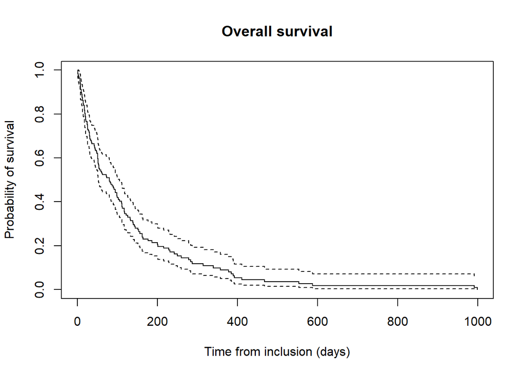

```r
plot(survfit(Surv(time, status) ~ 1,data=veteran) ,xlab="Time from inclusion (days)", ylab="Probability of survival", main="Overall survival")
```

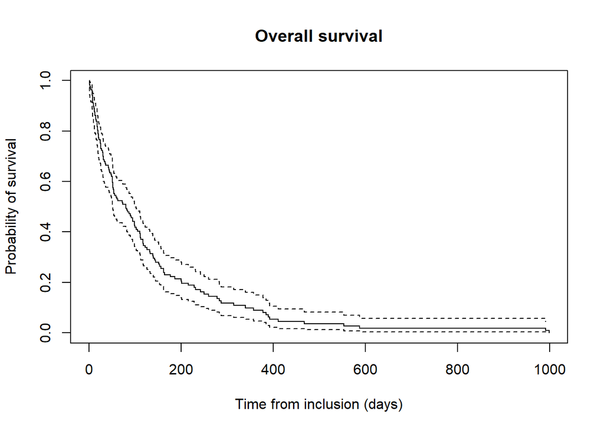

```r
plot(KM,xlab="Time from inclusion (days)", ylab="Probability of survival", main="Overall survival")
```

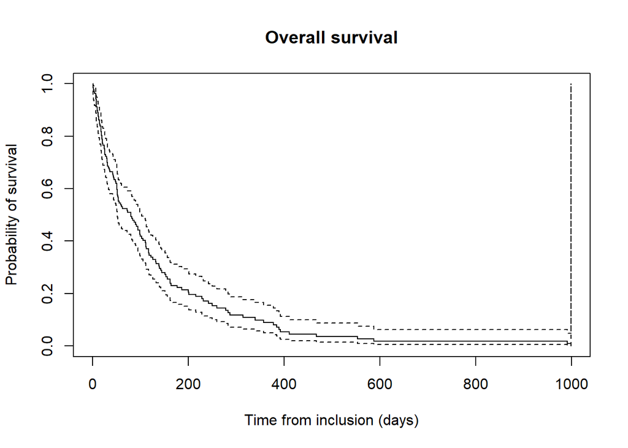

```r
plot(rothmanCI,xlab="Time from inclusion (days)", ylab="Probability of survival", main="Overall survival")
```

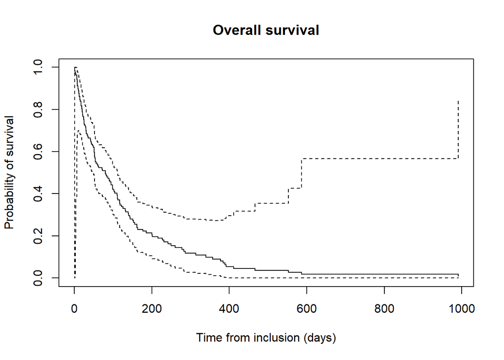

```r
plot(HWCB,xlab="Time from inclusion (days)", ylab="Probability of survival", main="Overall survival")
```

L’IC (ou la bande de confiance) correspond à celui demandé dans la fonction survfit utilisée pour la création de l’objet KM (ou rothmanCI, ou HWCB). Vous verrez qu’il y a une légère différence entre les 3 courbes, la première utilisant la méthode log (méthode par défaut), la seconde utilisant la méthode log-log, et la troisième utilisant la méthode de Rothman.

Afin d’embellir un peu notre rapport, nous pouvons utiliser le package *survminer* qui se base sur le package *ggplot2* pour fournir de plus jolis graphiques :

```r
library(survminer)
```

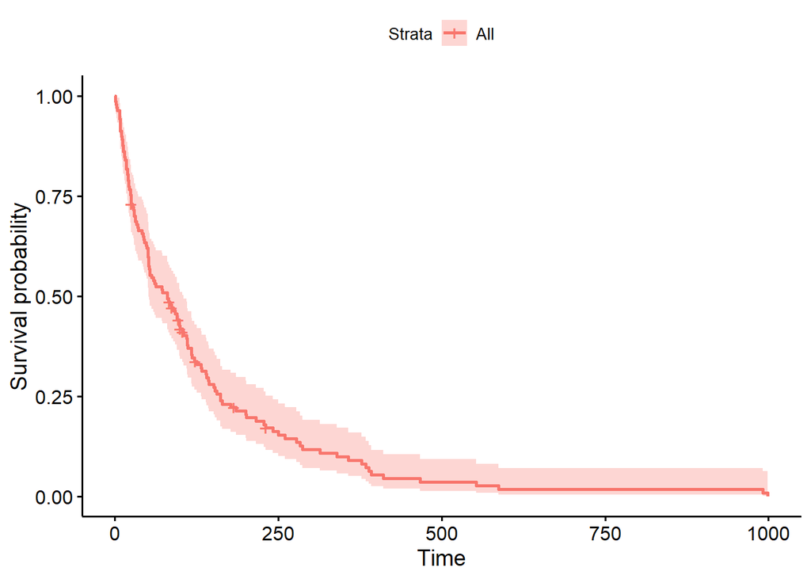

```r
ggsurvplot(survfit(Surv(time, status) ~ 1,data=veteran))
```

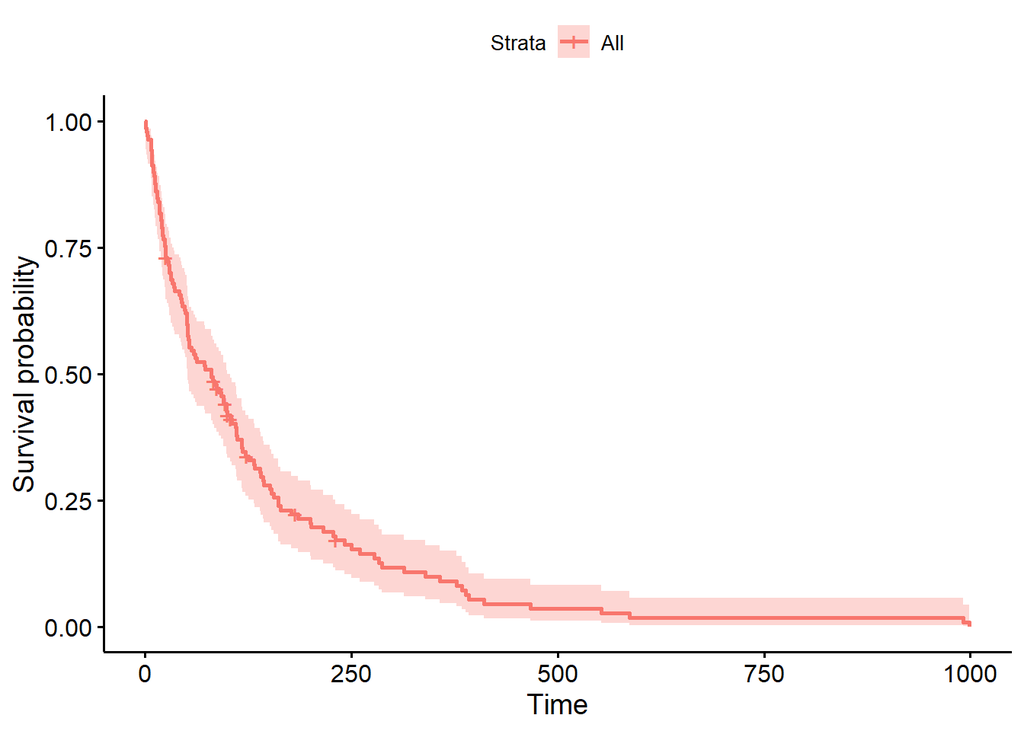

```r
ggsurvplot(KM)
```

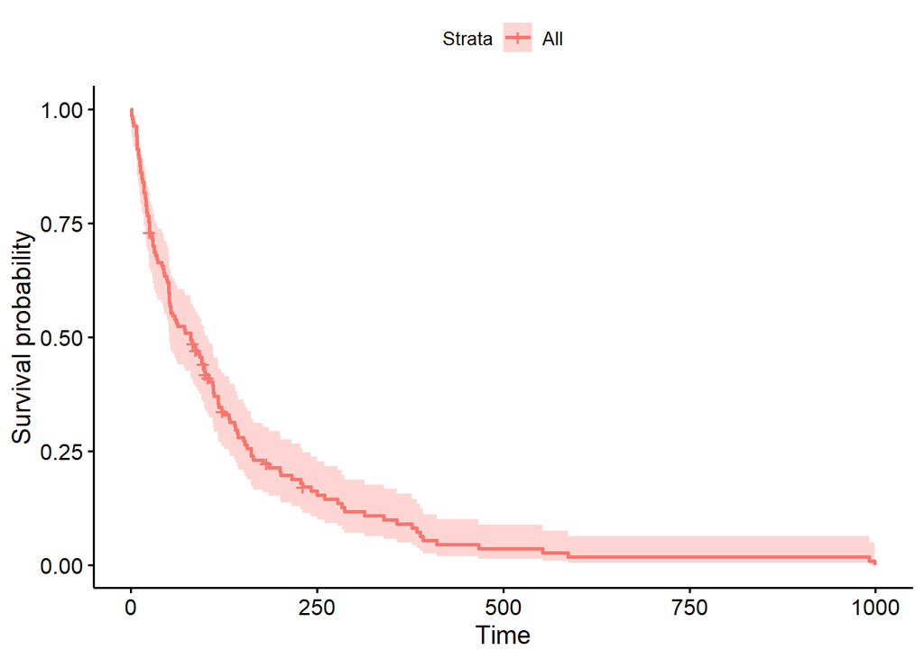

```r
ggsurvplot(rothmanCI)
```

Tout comme la méthode précédente, nous voyons que l’IC dépend bien de celui utilisé. La bande de confiance n’est malheureusement pas supportée par défaut par ce package. Un code plus complexe sera proposé dans une version ultérieure de ce notebook.

Le gros avantage de ce package est qu’il permet d’afficher une table d’effectifs sous le graphique, très souvent demandée pour les articles scientifiques :

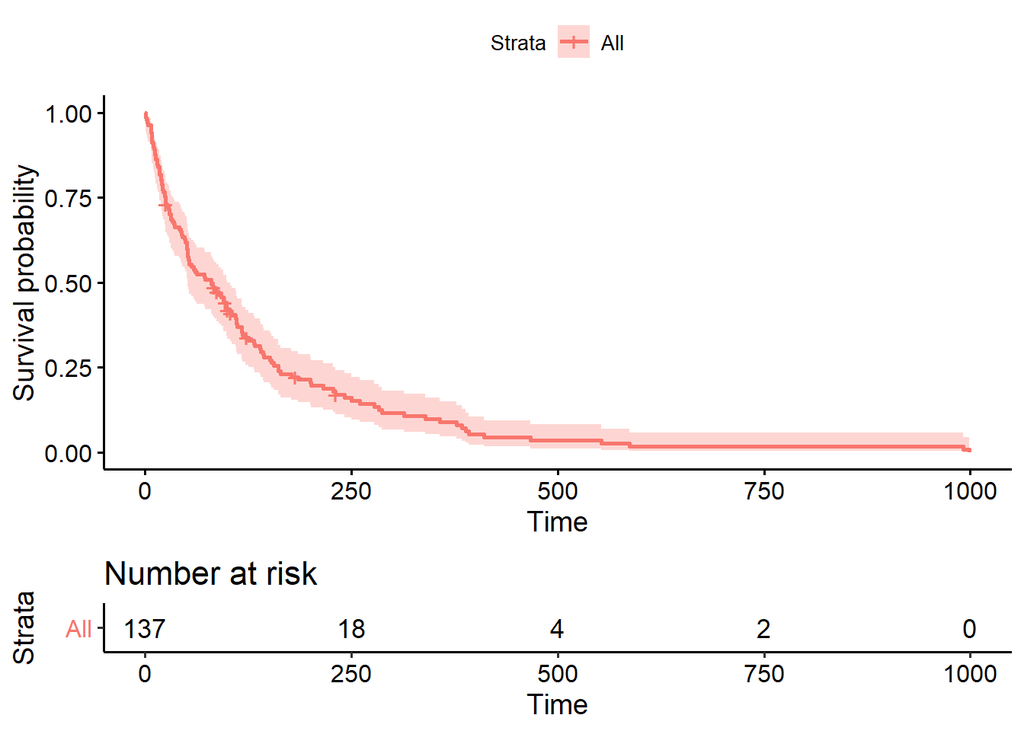

```r
ggsurvplot(KM,risk.table = TRUE)
```

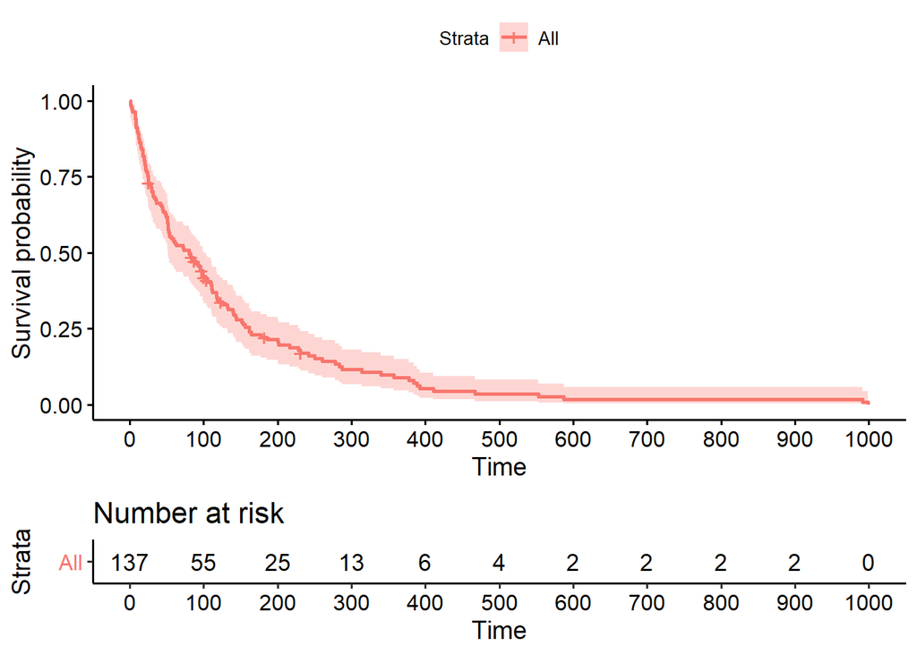

```r
ggsurvplot(KM,risk.table = TRUE,break.time.by = 100) #l'option breaktime est là pour indiquer à quels moment l'effectif doit être calculé pour la table
```

### Echelle de temps

Si le temps en jour ne nous convient pas, il suffit d’effectuer une simple transformation dans la fonction survfit pour obtenir l’échelle en mois ou en années :

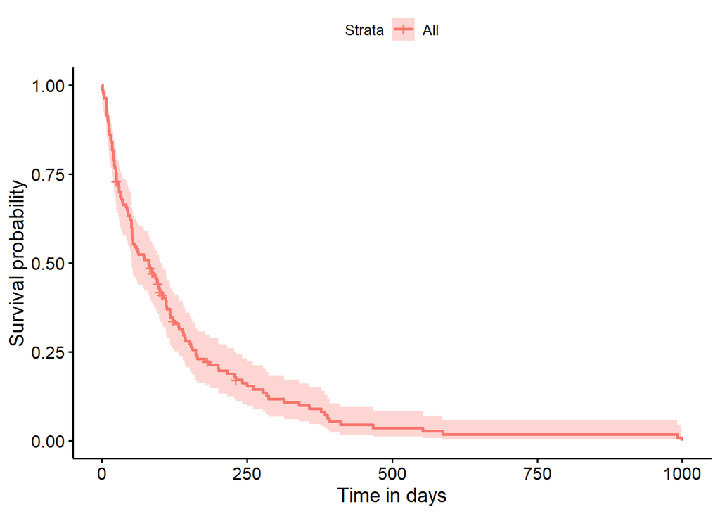

```r
ggsurvplot(survfit(Surv(time, status) ~ 1,data=veteran,conf.type="log-log"),xlab="Time in days")
```

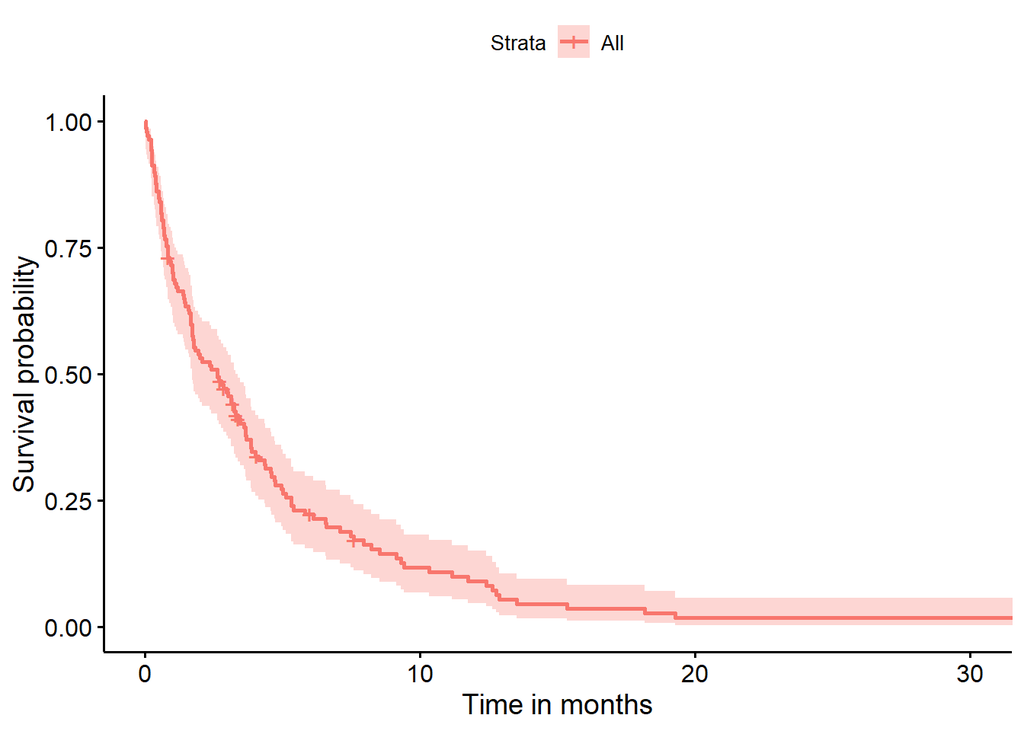

```r
ggsurvplot(survfit(Surv(time/30.4375, status) ~ 1,data=veteran,conf.type="log-log"),xlab="Time in months")
```

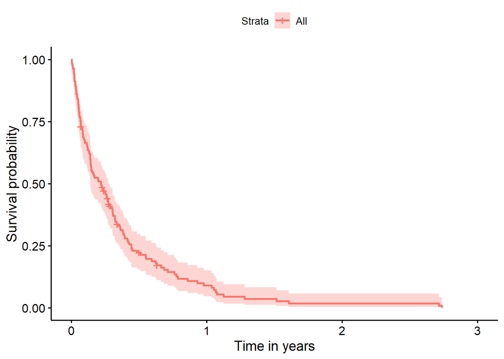

```r
ggsurvplot(survfit(Surv(time/365.25, status) ~ 1,data=veteran,conf.type="log-log"),xlab="Time in years")
```

Bien sur, cela serait plus précis d’utiliser la fonction *difftime* à partir des dates que vous avez utilisées pour calculer vos temps.

# Analyse de survie ajustée et test du logrank

## Estimateur de Kaplan-Meier

L’estimateur de Kaplan-Meier peut être ajusté en remplaçant le “1” dans la formule par le nom de la variable d’intérêt, ici *trt* :

```r
KM<-survfit(Surv(time, status) ~ trt,data=veteran)
#summary(KM) #affiche les tables de calcul des probabilités, 1 par traitement (non affichées ici par soucis de clarté)
```

Comme précédemment, nous pouvons obtenir la médiane de survie et son IC95% pour chaque groupe, simplement en écrivant le nom de l’objet créé précédément :

```r
KM
```

```
## Call: survfit(formula = Surv(time, status) ~ trt, data = veteran)
##
##        n events median 0.95LCL 0.95UCL
## trt=1 69     64  103.0      59     132
## trt=2 68     64   52.5      44      95
```

## Test du logrank

La fonction pour réaliser le test du logrank est la fonction *survdiff* qui s’utilise comme la fonction survfit :

```r
survdiff(Surv(time, status) ~ trt,data=veteran)
```

```
## Call:
## survdiff(formula = Surv(time, status) ~ trt, data = veteran)
##
##        N Observed Expected (O-E)^2/E (O-E)^2/V
## trt=1 69       64     64.5   0.00388   0.00823
## trt=2 68       64     63.5   0.00394   0.00823
##
##  Chisq= 0  on 1 degrees of freedom, p= 0.9
```

Ici, nous n’observons pas de différence significative entre les 2 bras. Pour une valeur précise de la p-value, il suffit d’extraire la valeur de la statistique de test de l’objet *survdiff*, et de calculer la p-value à partir du test du chi2 :

```r
1-pchisq(survdiff(Surv(time, status) ~ trt,data=veteran)$chisq,1)
```

```
## [1] 0.9277272
```

## Affichage des courbes

Comme précédemment, il suffit d’utiliser la fonction ggsurvplot, qui permet également d’afficher la p-value du logrank :

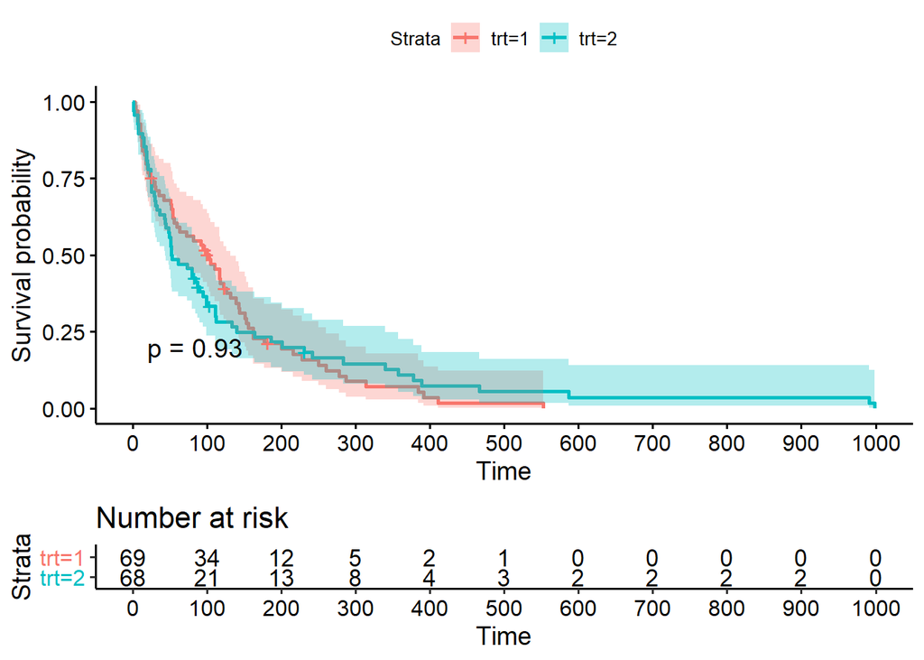

```r
ggsurvplot(KM,conf.int = TRUE,risk.table = TRUE,break.time.by = 100,pval = TRUE)
```

# A vous de jouer

## Exercice 1

Refaites les manipulations du paragraphe précédent, mais ajustez sur la variable *celltype* au lieu du traitement. Les groupes sont-ils différents ? Que préconisez-vous de faire dans cette situation ?

## Exercice 2

Ajustez sur *trt* et *celltype*